# py_tensorflow_binaryclass_kaggle_tabular_playground_2021nov

### Binary Classification Model for Kaggle Tabular Playground Series November 2021 Using Python and TensorFlow

### December 10, 2021

Template Credit: Adapted from a template made available by Dr. Jason Brownlee of Machine Learning Mastery. [https://machinelearningmastery.com/]

SUMMARY: This project aims to construct a predictive model using various machine learning algorithms and document the end-to-end steps using a template. The Kaggle Tabular Playground November 2021 dataset is a binary classification situation where we attempt to predict one of the two possible outcomes.

INTRODUCTION: Kaggle wants to provide an approachable environment for relatively new people in their data science journey. Since January 2021, they have hosted playground-style competitions on Kaggle with fun but less complex, tabular datasets. The dataset used for this competition is synthetic but based on a real dataset and generated using a CTGAN. The data is synthetically generated by a GAN trained on a real-world dataset used to identify spam emails via various extracted features from the email. Although the features are anonymized, they have properties relating to real-world features.

Dataset Used: Kaggle Tabular Playground 2021 November Data Set

Dataset ML Model: Binary classification with numerical attributes

Dataset Reference: https://www.kaggle.com/c/tabular-playground-series-nov-2021

One potential source of performance benchmark: https://www.kaggle.com/c/tabular-playground-series-nov-2021/leaderboard

## Task 1 - Prepare Environment

```python
# Install the necessary packages for Colab
# !pip install python-dotenv PyMySQL
```

```python
# # Retrieve the GPU information from Colab
# gpu_info = !nvidia-smi
# gpu_info = '\n'.join(gpu_info)
# if gpu_info.find('failed') >= 0:
#     print('Select the Runtime → "Change runtime type" menu to enable a GPU accelerator, ')
#     print('and then re-execute this cell.')
# else:
#     print(gpu_info)
```

```python
# # Retrieve the memory configuration from Colab
# from psutil import virtual_memory
# ram_gb = virtual_memory().total / 1e9
# print('Your runtime has {:.1f} gigabytes of available RAM\n'.format(ram_gb))

# if ram_gb < 20:
#     print('To enable a high-RAM runtime, select the Runtime → "Change runtime type"')
#     print('menu, and then select High-RAM in the Runtime shape dropdown. Then, ')
#     print('re-execute this cell.')
# else:
#     print('You are using a high-RAM runtime!')
```

```python
# Retrieve the CPU information
ncpu = !nproc
print("The number of available CPUs is:", ncpu[0])
```

```
The number of available CPUs is: 8
```

### 1.a) Load libraries and modules

```python
# Set the random seed number for reproducible results
RNG_SEED = 888
```

```python
import random
random.seed(RNG_SEED)
import numpy as np
np.random.seed(RNG_SEED)
import pandas as pd
# import seaborn as sns
import matplotlib.pyplot as plt
import os
import sys
import math
from datetime import datetime
# import boto3
# from dotenv import load_dotenv
from sklearn import preprocessing
from sklearn.model_selection import train_test_split
from sklearn.model_selection import RepeatedKFold
from sklearn.pipeline import Pipeline
from sklearn import compose
from sklearn import impute
import tensorflow as tf
tf.random.set_seed(RNG_SEED)
from tensorflow import keras
from tensorflow.keras.callbacks import ReduceLROnPlateau
```

### 1.b) Set up the controlling parameters and functions

```python
# Begin the timer for the script processing
start_time_script = datetime.now()

# Set up the number of CPU cores available for multi-thread processing
N_JOBS = 1

# Set up the flag to stop sending progress emails (setting to True will send status emails!)
NOTIFY_STATUS = False

# Set the percentage sizes for splitting the dataset
TEST_SET_RATIO = 0.2
VAL_SET_RATIO = 0.2

# Set the number of folds for cross validation
N_FOLDS = 5
N_ITERATIONS = 1

# Set various default modeling parameters
DEFAULT_LOSS = 'binary_crossentropy'
DEFAULT_METRICS = [tf.keras.metrics.AUC()]
DEFAULT_OPTIMIZER = tf.keras.optimizers.Adam(learning_rate=0.001)
DEFAULT_INITIALIZER = tf.keras.initializers.RandomNormal(seed=RNG_SEED)
CLASSIFIER_ACTIVATION = 'sigmoid'
MAX_EPOCHS = 20
BATCH_SIZE = 32

# Define the labels to use for graphing the data
train_metric = "auc"
validation_metric = "val_auc"
train_loss = "loss"
validation_loss = "val_loss"

# Check the number of GPUs accessible through TensorFlow
print('Num GPUs Available:', len(tf.config.list_physical_devices('GPU')))

# Print out the TensorFlow version for confirmation
print('TensorFlow version:', tf.__version__)
```

[output not shown]

```
Num GPUs Available: 1
TensorFlow version: 2.6.0
```

[output not shown]

```python
# Set up the email notification function
def status_notify(msg_text):
    access_key = os.environ.get('SNS_ACCESS_KEY')
    secret_key = os.environ.get('SNS_SECRET_KEY')
    aws_region = os.environ.get('SNS_AWS_REGION')
    topic_arn = os.environ.get('SNS_TOPIC_ARN')
    if (access_key is None) or (secret_key is None) or (aws_region is None):
        sys.exit("Incomplete notification setup info. Script Processing Aborted!!!")
    sns = boto3.client('sns', aws_access_key_id=access_key, aws_secret_access_key=secret_key, region_name=aws_region)
    response = sns.publish(TopicArn=topic_arn, Message=msg_text)
    if response['ResponseMetadata']['HTTPStatusCode'] != 200 :
        print('Status notification not OK with HTTP status code:', response['ResponseMetadata']['HTTPStatusCode'])
```

```python
# Reset the random number generators
def reset_random(x=RNG_SEED):
    random.seed(x)
    np.random.seed(x)
    tf.random.set_seed(x)
```

```python
if NOTIFY_STATUS: status_notify("Task 1 - Prepare Environment has begun! " + datetime.now().strftime('%a %B %d, %Y %I:%M:%S %p'))
```

### 1.c) Load dataset

```python
dataset_path = 'https://dainesanalytics.com/datasets/kaggle-tabular-playground-2021nov/train.csv'
df_dataset_import = pd.read_csv(dataset_path, index_col=False)

# Take a peek at the dataframe after import
print(df_dataset_import.head())
```

```
   id        f0       f1        f2       f3        f4       f5       f6  \
0   0  0.106643  3.59437  132.8040  3.18428  0.081971  1.18859  3.73238
1   1  0.125021  1.67336   76.5336  3.37825  0.099400  5.09366  1.27562
2   2  0.036330  1.49747  233.5460  2.19435  0.026914  3.12694  5.05687
3   3 -0.014077  0.24600  779.9670  1.89064  0.006948  1.53112  2.69800
4   4 -0.003259  3.71542  156.1280  2.14772  0.018284  2.09859  4.15492

         f7       f8  ...      f91       f92       f93       f94       f95  \
0  2.266270  2.09959  ...  1.09862  0.013331 -0.011715  0.052759  0.065400
1 -0.471318  4.54594  ...  3.46017  0.017054  0.124863  0.154064  0.606848
2  3.849460  1.80187  ...  4.88300  0.085222  0.032396  0.116092 -0.001688
3  4.517330  4.50332  ...  3.47439 -0.017103 -0.008100  0.062013  0.041193
4 -0.038236  3.37145  ...  1.91059 -0.042943  0.105616  0.125072  0.037509

        f96      f97       f98       f99  target
0  4.211250  1.97877  0.085974  0.240496       0
1 -0.267928  2.57786 -0.020877  0.024719       0
2 -0.520069  2.14112  0.124464  0.148209       0
3  0.511657  1.96860  0.040017  0.044873       0
4  1.043790  1.07481 -0.012819  0.072798       1

[5 rows x 102 columns]
```

```python
df_dataset_import.info(verbose=True)
```

```
<class 'pandas.core.frame.DataFrame'>
RangeIndex: 600000 entries, 0 to 599999
Data columns (total 102 columns):
 #    Column  Dtype
---   ------  -----
 0    id      int64
 1    f0      float64
 2    f1      float64
 3    f2      float64
 4    f3      float64
 5    f4      float64
 6    f5      float64
 7    f6      float64
 8    f7      float64
 9    f8      float64
```

[output cut: 94 more lines]

```python
print(df_dataset_import.describe())
```

```
                  id             f0             f1             f2  \
count  600000.000000  600000.000000  600000.000000  600000.000000
mean   299999.500000       0.306508       2.497590     306.644536
std    173205.225094       0.522450       1.554018     551.743893
min         0.000000      -3.797450      -1.223960   -1842.530000
25%    149999.750000       0.026222       1.186238      43.573400
50%    299999.500000       0.097788       2.516500     133.626000
75%    449999.250000       0.397184       3.787630     302.262250
max    599999.000000       8.781500       6.226720    6119.280000

                  f3             f4             f5             f6  \
count  600000.000000  600000.000000  600000.000000  600000.000000
mean        2.647901       0.177850       2.556832       2.699650
std         1.544529       0.417488       1.562527       1.564000
min        -1.368560      -3.206210      -1.169770      -1.059310
25%         1.442028       0.019709       1.261038       1.385820
50%         2.634130       0.061586       2.590425       2.801255
75%         3.907640       0.112712       3.813662       3.996913
max         6.521150       8.265470       6.515070       6.586780

                  f7             f8  ...            f91            f92  \
count  600000.000000  600000.000000  ...  600000.000000  600000.000000
mean        2.571593       2.538273  ...       2.444471       0.155260
std         1.549361       1.532988  ...       1.542509       0.548397
min        -1.281970      -1.242020  ...      -1.217700      -9.761770
25%         1.333848       1.292163  ...       1.214178       0.018904
50%         2.557985       2.475880  ...       2.386845       0.068906
75%         3.823450       3.804360  ...       3.693872       0.125165
max         6.258770       6.389670  ...       6.573890      18.412800

                 f93            f94            f95            f96  \
count  600000.000000  600000.000000  600000.000000  600000.000000
mean        0.059407       0.144932       0.106419       2.547853
std         0.119426       0.462015       0.209128       1.558427
min        -4.666240      -3.101500      -1.276540      -1.584740
25%         0.024483       0.017055       0.025461       1.247888
50%         0.056649       0.063439       0.062151       2.601940
75%         0.088162       0.113114       0.102016       3.820665
max        10.211800       8.623270       3.657220       6.254360

                 f97            f98            f99         target
count  600000.000000  600000.000000  600000.000000  600000.000000
mean        2.590159       0.158881       0.123048       0.506010
std         1.525091       0.436190       0.264896       0.499964
min        -1.254730      -3.993500      -2.783380       0.000000
25%         1.348078       0.013536       0.018105       0.000000
50%         2.682090       0.058058       0.058471       1.000000
75%         3.839520       0.110718       0.104872       1.000000
max         6.145300      10.767000       5.988110       1.000000

[8 rows x 102 columns]
```

```python
print(df_dataset_import.isnull().sum())
print('Total number of NaN in the dataframe: ', df_dataset_import.isnull().sum().sum())
```

```
id        0
f0        0
f1        0
f2        0
f3        0
         ..
f96       0
f97       0
f98       0
f99       0
target    0
Length: 102, dtype: int64
Total number of NaN in the dataframe:  0
```

### 1.d) Data Cleaning

```python
# Dropping features
df_dataset_import.drop(columns=['id'], inplace=True)

# Take a peek at the dataframe after cleaning
print(df_dataset_import.head())
```

```
         f0       f1        f2       f3        f4       f5       f6        f7  \
0  0.106643  3.59437  132.8040  3.18428  0.081971  1.18859  3.73238  2.266270
1  0.125021  1.67336   76.5336  3.37825  0.099400  5.09366  1.27562 -0.471318
2  0.036330  1.49747  233.5460  2.19435  0.026914  3.12694  5.05687  3.849460
3 -0.014077  0.24600  779.9670  1.89064  0.006948  1.53112  2.69800  4.517330
4 -0.003259  3.71542  156.1280  2.14772  0.018284  2.09859  4.15492 -0.038236

        f8        f9  ...      f91       f92       f93       f94       f95  \
0  2.09959  0.012330  ...  1.09862  0.013331 -0.011715  0.052759  0.065400
1  4.54594  0.037706  ...  3.46017  0.017054  0.124863  0.154064  0.606848
2  1.80187  0.056995  ...  4.88300  0.085222  0.032396  0.116092 -0.001688
3  4.50332  0.123494  ...  3.47439 -0.017103 -0.008100  0.062013  0.041193
4  3.37145  0.034166  ...  1.91059 -0.042943  0.105616  0.125072  0.037509

        f96      f97       f98       f99  target
0  4.211250  1.97877  0.085974  0.240496       0
1 -0.267928  2.57786 -0.020877  0.024719       0
2 -0.520069  2.14112  0.124464  0.148209       0
3  0.511657  1.96860  0.040017  0.044873       0
4  1.043790  1.07481 -0.012819  0.072798       1

[5 rows x 101 columns]
```

```python
df_dataset_import.info(verbose=True)
```

```
<class 'pandas.core.frame.DataFrame'>
RangeIndex: 600000 entries, 0 to 599999
Data columns (total 101 columns):
 #    Column  Dtype
---   ------  -----
 0    f0      float64
 1    f1      float64
 2    f2      float64
 3    f3      float64
 4    f4      float64
 5    f5      float64
 6    f6      float64
 7    f7      float64
 8    f8      float64
 9    f9      float64
```

[output cut: 93 more lines]

```python
print(df_dataset_import.describe())
```

```
                  f0             f1             f2             f3  \
count  600000.000000  600000.000000  600000.000000  600000.000000
mean        0.306508       2.497590     306.644536       2.647901
std         0.522450       1.554018     551.743893       1.544529
min        -3.797450      -1.223960   -1842.530000      -1.368560
25%         0.026222       1.186238      43.573400       1.442028
50%         0.097788       2.516500     133.626000       2.634130
75%         0.397184       3.787630     302.262250       3.907640
max         8.781500       6.226720    6119.280000       6.521150

                  f4             f5             f6             f7  \
count  600000.000000  600000.000000  600000.000000  600000.000000
mean        0.177850       2.556832       2.699650       2.571593
std         0.417488       1.562527       1.564000       1.549361
min        -3.206210      -1.169770      -1.059310      -1.281970
25%         0.019709       1.261038       1.385820       1.333848
50%         0.061586       2.590425       2.801255       2.557985
75%         0.112712       3.813662       3.996913       3.823450
max         8.265470       6.515070       6.586780       6.258770

                  f8             f9  ...            f91            f92  \
count  600000.000000  600000.000000  ...  600000.000000  600000.000000
mean        2.538273       0.134370  ...       2.444471       0.155260
std         1.532988       0.421892  ...       1.542509       0.548397
min        -1.242020      -2.577840  ...      -1.217700      -9.761770
25%         1.292163       0.019563  ...       1.214178       0.018904
50%         2.475880       0.058752  ...       2.386845       0.068906
75%         3.804360       0.101046  ...       3.693872       0.125165
max         6.389670       7.078460  ...       6.573890      18.412800

                 f93            f94            f95            f96  \
count  600000.000000  600000.000000  600000.000000  600000.000000
mean        0.059407       0.144932       0.106419       2.547853
std         0.119426       0.462015       0.209128       1.558427
min        -4.666240      -3.101500      -1.276540      -1.584740
25%         0.024483       0.017055       0.025461       1.247888
50%         0.056649       0.063439       0.062151       2.601940
75%         0.088162       0.113114       0.102016       3.820665
max        10.211800       8.623270       3.657220       6.254360

                 f97            f98            f99         target
count  600000.000000  600000.000000  600000.000000  600000.000000
mean        2.590159       0.158881       0.123048       0.506010
std         1.525091       0.436190       0.264896       0.499964
min        -1.254730      -3.993500      -2.783380       0.000000
25%         1.348078       0.013536       0.018105       0.000000
50%         2.682090       0.058058       0.058471       1.000000
75%         3.839520       0.110718       0.104872       1.000000
max         6.145300      10.767000       5.988110       1.000000

[8 rows x 101 columns]
```

```python
print(df_dataset_import.isnull().sum())
print('Total number of NaN in the dataframe: ', df_dataset_import.isnull().sum().sum())
```

```
f0        0
f1        0
f2        0
f3        0
f4        0
         ..
f96       0
f97       0
f98       0
f99       0
target    0
Length: 101, dtype: int64
Total number of NaN in the dataframe:  0
```

### 1.e) Splitting Data into Sets

```python
# Use variable total_column_count to hold the number of columns in the dataframe
total_column_count = len(df_dataset_import.columns)

# Set up variable total_feature_count for the total number of attribute columns
total_feature_count = total_column_count-1

# We create attribute-only and target-only datasets (df_features_train and df_target_train)
df_target_train = df_dataset_import['target']
df_features_train = df_dataset_import.drop(['target'], axis=1)

print("df_dataset_import.shape: {} df_features_train.shape: {} df_target_train.shape: {}".format(df_dataset_import.shape, df_features_train.shape, df_target_train.shape))
```

```
df_dataset_import.shape: (600000, 101) df_features_train.shape: (600000, 100) df_target_train.shape: (600000,)
```

### 1.f) Set up the parameters for data visualization

```python
# Set up the number of row and columns for visualization display. display_rows * display_columns should be >= total_feature_count
display_columns = 4
if total_feature_count % display_columns == 0 :
    display_rows = total_feature_count // display_columns
else :
    display_rows = (total_feature_count // display_columns) + 1

# Set figure width to display the data visualization plots
fig_size = plt.rcParams["figure.figsize"]
fig_size[0] = display_columns * 4
fig_size[1] = display_rows * 4
plt.rcParams["figure.figsize"] = fig_size
```

```python
if NOTIFY_STATUS: status_notify("Task 1 - Prepare Environment completed! "+datetime.now().strftime('%a %B %d, %Y %I:%M:%S %p'))
```

## Task 2 - Summarize and Visualize Data

```python
if NOTIFY_STATUS: status_notify("Task 2 - Summarize and Visualize Data has begun! "+datetime.now().strftime('%a %B %d, %Y %I:%M:%S %p'))
```

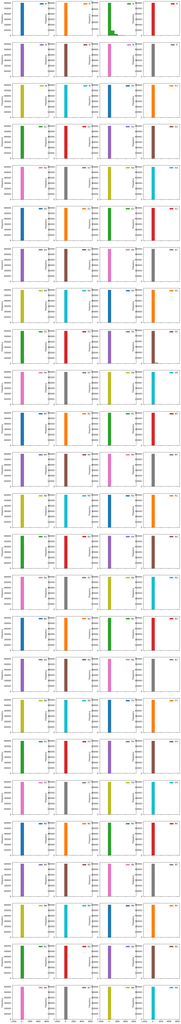

```python
# Histograms for each attribute
df_features_train.plot(kind='hist', subplots=True, layout=(display_rows, display_columns))
plt.show()
```

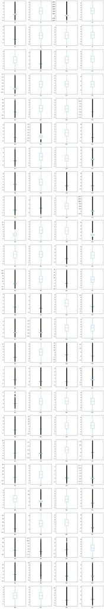

```python
# Box and Whisker plot for each attribute
df_features_train.plot(kind='box', subplots=True, layout=(display_rows, display_columns))
plt.show()
```

```python
# # Correlation matrix
# fig = plt.figure(figsize=(20,20))
# ax = fig.add_subplot(111)
# correlations = df_features_train.corr(method='pearson')
# cax = ax.matshow(correlations, vmin=-1, vmax=1)
# fig.colorbar(cax)
# plt.show()
```

```python
if NOTIFY_STATUS: status_notify("Task 2 - Summarize and Visualize Data completed! "+datetime.now().strftime('%a %B %d, %Y %I:%M:%S %p'))
```

## Task 3 - Pre-process Data

```python
if NOTIFY_STATUS: status_notify("Task 3 - Pre-process Data has begun! "+datetime.now().strftime('%a %B %d, %Y %I:%M:%S %p'))
```

### 3.a) Splitting Data into Training and Test Sets

```python
# Not applicable for this iteration of the project
```

### 3.b) Feature Scaling and Data Pre-Processing

```python
# # Compose pipeline for the numerical and categorical features (Block #1 of 2)
# numeric_columns = df_features_train.select_dtypes(include=['int64','float64']).columns
# numeric_transformer = Pipeline(steps=[
#     ('imputer', impute.SimpleImputer(strategy="constant", fill_value=0)),
#     ('scaler', preprocessing.MinMaxScaler())
# ])
# categorical_columns = df_features_train.select_dtypes(include=['object','bool','category']).columns
# categorical_transformer = Pipeline(steps=[
#     ('imputer', impute.SimpleImputer(strategy='constant', fill_value='UKNOWN')),
#     ('onehot', preprocessing.OneHotEncoder(sparse=False, handle_unknown='ignore'))
# ])

# print("Number of numerical columns:", len(numeric_columns))
# print("Number of categorical columns:", len(categorical_columns))
# print("Total number of columns in the feature dataframe:", df_features_train.shape[1])
```

```python
# # Compose pipeline for the numerical and categorical features (Block #2 of 2)
# preprocessor = compose.ColumnTransformer(transformers=[
#     ('num', numeric_transformer, numeric_columns),
#     ('cat', categorical_transformer, categorical_columns)
# ])

# # Display the shapes of the training dataset for final inspection
# array_features_train = preprocessor.fit_transform(df_features_train)
# print("Transformed features from df_features_train.shape: {} to array_features_train.shape: {}".format(df_features_train.shape, array_features_train.shape))
```

### 3.c) Training Data Balancing

```python
# Not applicable for this iteration of the project
```

### 3.d) Feature Selection

```python
# Not applicable for this iteration of the project
```

### 3.e) Display the Final Datasets for Model-Building

```python
# Finalize the training and validation datasets for the modeling activities
array_features_train = df_features_train.to_numpy()
array_target_train = df_target_train.ravel()
print("array_features_train.shape: {} array_target_train.shape: {}".format(array_features_train.shape, array_target_train.shape))
```

```
array_features_train.shape: (600000, 100) array_target_train.shape: (600000,)
```

```python
if NOTIFY_STATUS: status_notify("Task 3 - Pre-process Data completed! "+datetime.now().strftime('%a %B %d, %Y %I:%M:%S %p'))
```

## Task 4 - Train and Tune Models

```python
if NOTIFY_STATUS: status_notify("Task 4 - Train and Tune Models has begun! "+datetime.now().strftime('%a %B %d, %Y %I:%M:%S %p'))
```

```python
# Define the baseline model for benchmarking
def create_nn_model(input_param=array_features_train.shape[1], layer1_nodes=2048, layer2_nodes=2048, layer3_nodes=2048, layer4_nodes=2048, layer5_nodes=2048,
                    layer1_dropout=0.25, layer2_dropout=0.25, layer3_dropout=0.25, layer4_dropout=0.25, layer5_dropout=0.5,
                    init_param=DEFAULT_INITIALIZER, classifier_activation=CLASSIFIER_ACTIVATION,
                    loss_param=DEFAULT_LOSS, opt_param=DEFAULT_OPTIMIZER, metrics_param=DEFAULT_METRICS):
    nn_model = keras.Sequential([
        keras.layers.Dense(layer1_nodes, input_shape=(input_param,), activation='relu', kernel_initializer=init_param),
        keras.layers.Dropout(layer1_dropout),
        keras.layers.Dense(layer2_nodes, activation='relu', kernel_initializer=init_param),
        keras.layers.Dropout(layer2_dropout),
        keras.layers.Dense(layer3_nodes, activation='relu', kernel_initializer=init_param),
        keras.layers.Dropout(layer3_dropout),
        keras.layers.Dense(layer4_nodes, activation='relu', kernel_initializer=init_param),
        keras.layers.Dropout(layer4_dropout),
        keras.layers.Dense(layer5_nodes, activation='relu', kernel_initializer=init_param),
        keras.layers.Dropout(layer5_dropout),
        keras.layers.Dense(1, activation=classifier_activation)
    ])
    nn_model.compile(loss=loss_param, optimizer=opt_param, metrics=metrics_param)
    return nn_model
```

```python
# start_time_module = datetime.now()
# reset_random()
# baseline_model = create_nn_model()
# baseline_model.fit(array_features_train, array_target_train, epochs=MAX_EPOCHS, batch_size=BATCH_SIZE, verbose=1)
# print('Total time for model fitting and cross validating:', (datetime.now() - start_time_module))
```

```python
# Initialize the default model and get a baseline result
start_time_module = datetime.now()
learning_rate_reduction = ReduceLROnPlateau(monitor='val_accuracy', patience=3, verbose=1, factor=0.5, min_lr=0.000001)
results = list()
iteration = 0
cv = RepeatedKFold(n_splits=N_FOLDS, n_repeats=N_ITERATIONS, random_state=RNG_SEED)
for train_ix, val_ix in cv.split(array_features_train):
    feature_train, feature_validation = array_features_train[train_ix], array_features_train[val_ix]
    target_train, target_validation = array_target_train[train_ix], array_target_train[val_ix]
    reset_random()
    baseline_model = create_nn_model()
    baseline_model.fit(feature_train, target_train, epochs=MAX_EPOCHS, batch_size=BATCH_SIZE, verbose=0)
    model_metric = baseline_model.evaluate(feature_validation, target_validation, verbose=0)[1]
    iteration = iteration + 1
    print('Score from iteration %d >>> %.4f' % (iteration, model_metric))
    results.append(model_metric)
validation_score = np.mean(results)
validation_variance = np.std(results)
print('Average model scorer from all iterations: %.4f (%.4f)' % (validation_score, validation_variance))
print('Total time for model fitting and cross validating:', (datetime.now() - start_time_module))
```

```
2021-12-03 00:24:24.388564: I tensorflow/compiler/mlir/mlir_graph_optimization_pass.cc:185] None of the MLIR Optimization Passes are enabled (registered 2)
```

```
Score from iteration 1 >>> 0.5000
Score from iteration 2 >>> 0.7052
Score from iteration 3 >>> 0.7375
Score from iteration 4 >>> 0.5000
Score from iteration 5 >>> 0.7376
Average model scorer from all iterations: 0.6361 (0.1117)
Total time for model fitting and cross validating: 1:27:11.764704
```

```python
if NOTIFY_STATUS: status_notify("Task 4 - Train and Tune Models completed! "+datetime.now().strftime('%a %B %d, %Y %I:%M:%S %p'))
```

## Task 5 - Finalize Model and Make Predictions

```python
if NOTIFY_STATUS: status_notify("Task 5 - Finalize Model and Make Predictions has begun! "+datetime.now().strftime('%a %B %d, %Y %I:%M:%S %p'))
```

### 6.a) Train the Final Model

```python
learning_rate_reduction = ReduceLROnPlateau(monitor='auc', patience=3, verbose=1, factor=0.5, min_lr=0.00005)
final_model = create_nn_model()
# final_model.fit(array_features_train, array_target_train, epochs=MAX_EPOCHS, batch_size=BATCH_SIZE, callbacks=[learning_rate_reduction], verbose=1)
final_model.fit(array_features_train, array_target_train, epochs=MAX_EPOCHS, batch_size=BATCH_SIZE, verbose=0)
final_model.summary()
```

```
Model: "sequential_5"
_________________________________________________________________
Layer (type)                 Output Shape              Param #
=================================================================
dense_30 (Dense)             (None, 2048)              206848
_________________________________________________________________
dropout_25 (Dropout)         (None, 2048)              0
_________________________________________________________________
dense_31 (Dense)             (None, 2048)              4196352
_________________________________________________________________
dropout_26 (Dropout)         (None, 2048)              0
_________________________________________________________________
dense_32 (Dense)             (None, 2048)              4196352
_________________________________________________________________
dropout_27 (Dropout)         (None, 2048)              0
_________________________________________________________________
dense_33 (Dense)             (None, 2048)              4196352
_________________________________________________________________
dropout_28 (Dropout)         (None, 2048)              0
_________________________________________________________________
dense_34 (Dense)             (None, 2048)              4196352
_________________________________________________________________
dropout_29 (Dropout)         (None, 2048)              0
_________________________________________________________________
dense_35 (Dense)             (None, 1)                 2049
=================================================================
Total params: 16,994,305
Trainable params: 16,994,305
Non-trainable params: 0
_________________________________________________________________
```

### 6.b) Load Test Dataset and Prepare the Submission File

```python
dataset_path = 'https://dainesanalytics.com/datasets/kaggle-tabular-playground-2021nov/test.csv'
df_features_test = pd.read_csv(dataset_path, index_col=False)

# Take a peek at the dataframe after import
print(df_features_test.head())
```

```
       id        f0        f1       f2        f3        f4        f5  \
0  600000  0.003229  4.838660  585.529  2.282910  0.713180  3.907830
1  600001  0.008602  0.505536 -100.099  3.012670  0.027199  1.194610
2  600002  1.461000  2.437260 -112.964  3.541230  0.752338  4.338310
3  600003  0.140556  3.085610  179.451  0.573945  0.057342  2.216790
4  600004  0.128876  5.199760  107.466 -0.497149  0.080220  0.458121

         f6        f7        f8  ...       f90       f91       f92       f93  \
0  0.480696  1.482270  4.891810  ...  0.112910  1.073550  0.122149  0.086330
1  5.036620  2.517440  4.553890  ... -0.020214  2.622340  0.123307  0.033063
2  1.648080  4.699910  1.950250  ... -0.011036  2.030180 -0.000426  0.084091
3  1.623480  0.526174  1.542540  ...  0.050117  0.221613  0.045298  0.129966
4  0.629839  5.240460 -0.232279  ...  0.058860  2.660430  0.135425  0.036481

        f94       f95       f96       f97       f98       f99
0  0.036010  0.010619  0.290343  1.898200  0.131533  0.012047
1  0.123059  0.005771 -0.392923  3.689640  0.047418  0.120015
2  0.123605  0.499554  4.054650  3.330670  0.108843  0.064687
3  0.004015  0.018279  2.696580 -0.533491  0.052524  0.011058
4  0.093912  0.056315  1.110710  3.584470  0.145319 -0.050393

[5 rows x 101 columns]
```

```python
df_kaggle_submission = pd.DataFrame()
df_kaggle_submission['id'] = df_features_test['id']
print(df_kaggle_submission.head())
```

```
       id
0  600000
1  600001
2  600002
3  600003
4  600004
```

```python
# Dropping features
df_features_test.drop(columns=['id'], inplace=True)

# Take a peek at the dataframe after cleaning
print(df_features_test.head())
```

```
         f0        f1       f2        f3        f4        f5        f6  \
0  0.003229  4.838660  585.529  2.282910  0.713180  3.907830  0.480696
1  0.008602  0.505536 -100.099  3.012670  0.027199  1.194610  5.036620
2  1.461000  2.437260 -112.964  3.541230  0.752338  4.338310  1.648080
3  0.140556  3.085610  179.451  0.573945  0.057342  2.216790  1.623480
4  0.128876  5.199760  107.466 -0.497149  0.080220  0.458121  0.629839

         f7        f8        f9  ...       f90       f91       f92       f93  \
0  1.482270  4.891810  0.056351  ...  0.112910  1.073550  0.122149  0.086330
1  2.517440  4.553890  0.063876  ... -0.020214  2.622340  0.123307  0.033063
2  4.699910  1.950250  0.005303  ... -0.011036  2.030180 -0.000426  0.084091
3  0.526174  1.542540 -0.026160  ...  0.050117  0.221613  0.045298  0.129966
4  5.240460 -0.232279  0.030006  ...  0.058860  2.660430  0.135425  0.036481

        f94       f95       f96       f97       f98       f99
0  0.036010  0.010619  0.290343  1.898200  0.131533  0.012047
1  0.123059  0.005771 -0.392923  3.689640  0.047418  0.120015
2  0.123605  0.499554  4.054650  3.330670  0.108843  0.064687
3  0.004015  0.018279  2.696580 -0.533491  0.052524  0.011058
4  0.093912  0.056315  1.110710  3.584470  0.145319 -0.050393

[5 rows x 100 columns]
```

```python
# Finalize the test dataset for the modeling testing
array_features_test = df_features_test.to_numpy()
print("Transformed features from df_features_test.shape: {} to array_features_test.shape: {}".format(df_features_test.shape, array_features_test.shape))
```

```
Transformed features from df_features_test.shape: (540000, 100) to array_features_test.shape: (540000, 100)
```

```python
# Make batched predictions
test_predictions = final_model.predict(array_features_test)
print(test_predictions)
```

```
[[0.7347679 ]
 [0.7347679 ]
 [0.7347679 ]
 ...
 [0.50443524]
 [0.7347679 ]
 [0.7347679 ]]
```

```python
df_kaggle_submission['target'] = test_predictions
print(df_kaggle_submission.head())
```

```
       id    target
0  600000  0.734768
1  600001  0.734768
2  600002  0.734768
3  600003  0.420255
4  600004  0.689863
```

```python
submission_file = df_kaggle_submission.to_csv(header=True, index=False)
filename = 'submission_' + datetime.now().strftime('%Y%m%d-%H%M') + '.csv'
with open(filename, 'w') as f:
    f.write(submission_file)
    print('Completed writing output file: ' + filename)
```

```
Completed writing output file: submission_20211203-0239.csv
```

```python
if NOTIFY_STATUS: status_notify("Task 5 - Finalize Model and Make Predictions completed! "+datetime.now().strftime('%a %B %d, %Y %I:%M:%S %p'))
```

```python
print ('Total time for the script:',(datetime.now() - start_time_script))
```

```
Total time for the script: 2:16:30.261451
```